[figure not shown]

Profesor:[Dr. José Manuel MAGALLANES REYES, Ph.D](http://www.pucp.edu.pe/profesor/jose-manuel-magallanes/%22%20target=%22_blank)

- Profesor Principal del Departamento de Ciencias Sociales, Sección de Ciencia Política y Gobierno.
- [Oficina 223](https://goo.gl/maps/xuGeG6o9di1i1y5m6) - Edificio CISEPA / ECONOMIA / CCSS
- Telefono: (51) 1 - 6262000 anexo 4302
- Correo Electrónico: jmagallanes@pucp.edu.pe

# Operations on Data Frames

[RUN in GoogleColab](https://drive.google.com/file/d/1FUCy7zCFewQemw0K0hTyHizcYo3DEr30/view?usp=sharing)

## Aggregation

Let’s bring some data of COVID from [Brazil](https://infoms.saude.gov.br/extensions/covid-19_html/covid-19_html.html):

```r
rm(list = ls())
linkCovid='https://github.com/Estadistica-AnalisisPolitico/operations_onDFs/raw/refs/heads/main/data/BrasilCovid.rds'
dataCovid=readRDS(url(linkCovid))
```

Now, check the data available:

```r
str(dataCovid)
```

```
## 'data.frame':    1129419 obs. of  20 variables:
##  $ regiao                : chr  "Brasil" "Brasil" "Brasil" "Brasil" ...
##  $ estado                : chr  "" "" "" "" ...
##  $ municipio             : chr  "" "" "" "" ...
##  $ coduf                 : int  76 76 76 76 76 76 76 76 76 76 ...
##  $ codmun                : int  NA NA NA NA NA NA NA NA NA NA ...
##  $ codRegiaoSaude        : int  NA NA NA NA NA NA NA NA NA NA ...
##  $ nomeRegiaoSaude       : chr  "" "" "" "" ...
##  $ data                  : POSIXlt, format: "2022-01-01" "2022-01-02" ...
##  $ semanaEpi             : int  52 1 1 1 1 1 1 1 2 2 ...
##  $ populacaoTCU2019      : int  210147125 210147125 210147125 210147125 210147125 210147125 210147125 210147125 210147125 210147125 ...
##  $ casosAcumulado        : num  22291507 22293228 22305078 22323837 22351104 ...
##  $ casosNovos            : int  3986 1721 11850 18759 27267 35826 63292 49303 24382 34788 ...
##  $ obitosAcumulado       : int  619105 619133 619209 619384 619513 619641 619822 619937 619981 620091 ...
##  $ obitosNovos           : int  49 28 76 175 129 128 181 115 44 110 ...
##  $ Recuperadosnovos      : int  21581668 21581717 21591847 21603954 21615473 21626836 21650151 21652319 21634074 21636133 ...
##  $ emAcompanhamentoNovos : int  90734 92378 94022 100499 116118 140453 180249 227269 269852 302471 ...
##  $ interior.metropolitana: int  NA NA NA NA NA NA NA NA NA NA ...
##  $ day                   : chr  "01" "02" "03" "04" ...
##  $ year                  : chr  "2022" "2022" "2022" "2022" ...
##  $ month                 : chr  "01" "01" "01" "01" ...
```

Let’s keep complete data by “ESTADO”:

```r
dataCovid=dataCovid[dataCovid$estado!="",]
```

Let’s keep some columns:

```r
toSelect=c('regiao', 'estado', 'municipio','data', 'semanaEpi','casosNovos', 'obitosNovos','day','year','month')
covid=dataCovid[,toSelect]

head(covid)
```

```
##     regiao estado municipio       data semanaEpi casosNovos obitosNovos day
## 182  Norte     RO           2022-01-01        52         34           3  01
## 183  Norte     RO           2022-01-02         1         32           2  02
## 184  Norte     RO           2022-01-03         1         91           3  03
## 185  Norte     RO           2022-01-04         1        254           3  04
## 186  Norte     RO           2022-01-05         1        232           3  05
## 187  Norte     RO           2022-01-06         1        391           8  06
##     year month
## 182 2022    01
## 183 2022    01
## 184 2022    01
## 185 2022    01
## 186 2022    01
## 187 2022    01
```

Let’s find out about years available:

```r
unique(covid$year)
```

```
## [1] "2022"
```

```r
unique(covid$month)
```

```
## [1] "01" "02" "03" "04" "05" "06" "07"
```

So, we have data from January to July 2022. Let’s find out: **count of new positive cases per month**:

```r
for (month in unique(covid$month)) {
    print(paste(month,sum(covid$casosNovos[covid$month==month])))}
```

```
## [1] "01 6278446"
## [1] "02 6721752"
## [1] "03 2320550"
## [1] "04 1000682"
## [1] "05 1141604"
## [1] "06 2677960"
## [1] "07 2192552"
```

We use **aggregation** to simplify the previous steps:

```r
# sum of cases by month
casesSumByMonth=aggregate(data=covid,casosNovos~month,sum)
casesSumByMonth
```

```
##   month casosNovos
## 1    01    6278446
## 2    02    6721752
## 3    03    2320550
## 4    04    1000682
## 5    05    1141604
## 6    06    2677960
## 7    07    2192552
```

Notice the structure:

```r
is.data.frame(casesSumByMonth)
```

```
## [1] TRUE
```

**AGGREGATING** capabilities allow us to produce useful output with few code:

- **The groupings**:

In the last example, *month* was the **grouping** variable. We can have more than one:

```r
# sum of cases by estado and month
theModel=casosNovos~estado + month
theFun=sum
casesSumByStateAndMonth=aggregate(data=covid,
                                  theModel,
                                  theFun)
# see some
casesSumByStateAndMonth%>%head(30)
```

```
##    estado month casosNovos
## 1      AC    01      25752
## 2      AL    01      32320
## 3      AM    01     192126
## 4      AP    01      49954
## 5      BA    01     184908
## 6      CE    01     336702
## 7      DF    01     173908
## 8      ES    01     426590
## 9      GO    01     178684
## 10     MA    01      31844
## 11     MG    01     979192
## 12     MS    01      85678
## 13     MT    01     142290
## 14     PA    01      45352
```

[output cut: 16 more lines]

- **The function to apply**:

We can have more than one function:

```r
# sum and mean of cases by estado and week
theModel=casosNovos~estado + semanaEpi
theFun=function(x) c(mean = mean(x), sum = sum(x) )
casesSumAndMeanByStateAndWeek=aggregate(data=covid,
                                        theModel,
                                        theFun)

# sometimes you can not see this (when in RStudio)
# see some
casesSumAndMeanByStateAndWeek%>%head(30)
```

```
##    estado semanaEpi casosNovos.mean casosNovos.sum
## 1      AC         1    2.111801e-01   3.400000e+01
## 2      AL         1    1.815934e+00   1.322000e+03
## 3      AM         1    6.956916e+00   3.068000e+03
## 4      AP         1    7.848739e+00   9.340000e+02
## 5      BA         1    3.957041e+00   1.160600e+04
## 6      CE         1    6.089094e+00   7.928000e+03
## 7      DF         1    7.292857e+02   1.021000e+04
## 8      ES         1    1.676786e+01   9.390000e+03
## 9      GO         1    6.292627e+00   1.092400e+04
## 10     MA         1    1.608611e+00   2.466000e+03
## 11     MG         1    1.108438e+01   6.634000e+04
## 12     MS         1    1.135357e+01   6.358000e+03
## 13     MT         1    1.025375e+01   1.026400e+04
## 14     PA         1    6.492611e+00   6.590000e+03
```

[output cut: 16 more lines]

If you do not see the above result, turn the aggregation explicitly into a dataframe:

```r
casesSumAndMeanByStateAndWeek=do.call(data.frame,
                                      aggregate(data=covid,
                                                theModel,
                                                theFun))
# see some
casesSumAndMeanByStateAndWeek%>%head(30)
```

```
##    estado semanaEpi casosNovos.mean casosNovos.sum
## 1      AC         1       0.2111801             34
## 2      AL         1       1.8159341           1322
## 3      AM         1       6.9569161           3068
## 4      AP         1       7.8487395            934
## 5      BA         1       3.9570406          11606
## 6      CE         1       6.0890937           7928
## 7      DF         1     729.2857143          10210
## 8      ES         1      16.7678571           9390
## 9      GO         1       6.2926267          10924
## 10     MA         1       1.6086106           2466
## 11     MG         1      11.0843776          66340
## 12     MS         1      11.3535714           6358
## 13     MT         1      10.2537463          10264
## 14     PA         1       6.4926108           6590
```

[output cut: 16 more lines]

- **The variables transformed**:

We can apply the function to more than one variable:

```r
# sum of cases and deaths by estado
theModel=cbind(casosNovos,obitosNovos)~estado
theFun=sum
CasesAndDeathsByState=aggregate(data=covid,
                                theModel,
                                theFun)

# see some
CasesAndDeathsByState%>%head(30)
```

```
##    estado casosNovos obitosNovos
## 1      AC      98212         318
## 2      AL     147788        1302
## 3      AM     330308         734
## 4      AP      91570         254
## 5      BA     739720        5438
## 6      CE     776922        5106
## 7      DF     613688        1406
## 8      ES    1116860        2594
## 9      GO    1279760        4834
## 10     MA     167962        1088
## 11     MG    3096646       11986
## 12     MS     360654        1906
## 13     MT     489366        2058
## 14     PA     344476        2822
## 15     PB     348380        1458
## 16     PE     742412        3074
## 17     PI      95070        1136
## 18     PR    2148870        6822
## 19     RJ    2142644       10174
## 20     RN     310882        1508
## 21     RO     305848        1092
## 22     RR      82642         160
## 23     RS    2208120        7778
## 24     SC    1164718        3972
## 25     SE     120602         676
## 26     SP    2810310       34144
## 27     TO     199116         482
```

- Function **according** to variable

The function can vary according to variable. In this case, using **dplyr** is needed:

```r
library(dplyr)
covid |>
  group_by(month) |>
  summarize(casosNovos_VAR = var(casosNovos),
            casosNovos_SD = sd(casosNovos),
            obitosNovos_Median = median(obitosNovos),
            obitosNovos_Mean = mean(obitosNovos))
```

```
## # A tibble: 7 × 5
##   month casosNovos_VAR casosNovos_SD obitosNovos_Median obitosNovos_Mean
##   <chr>          <dbl>         <dbl>              <dbl>            <dbl>
## 1 01           326469.          571.                  0           0.0928
## 2 02           306067.          553.                  0           0.282
## 3 03            72433.          269.                  0           0.120
## 4 04            82382.          287.                  0           0.0444
## 5 05            89456.          299.                  0           0.0365
## 6 06            61557.          248.                  0           0.0562
## 7 07            74894.          274.                  0           0.0855
```

## Concatenation

As the name implies, it is the process to unite dataframes.

For this example, there is a webpage in **[fragilestatesindex.org](https://fragilestatesindex.org/excel/)** where we can find several links to excel files. Let me get all the links:

```r
library(rvest)

# Read the HTML content of the website
webpage <- read_html("https://fragilestatesindex.org/excel/")


allLinks=html_nodes(webpage,"table") %>%
            html_nodes("a") %>% #“a” nodes contain linked text.
                html_attr("href")%>% # the url (an html attribute)
                    trimws()%>%unique() # cleaning and keeping non duplicated
allLinks
```

```
##  [1] "https://fragilestatesindex.org/wp-content/uploads/2023/06/FSI-2023-DOWNLOAD.xlsx"
##  [2] "https://fragilestatesindex.org/wp-content/uploads/2022/07/fsi-2022-download.xlsx"
##  [3] "https://fragilestatesindex.org/wp-content/uploads/2021/05/fsi-2021.xlsx"
##  [4] "https://fragilestatesindex.org/wp-content/uploads/2020/05/fsi-2020.xlsx"
##  [5] "https://fragilestatesindex.org/wp-content/uploads/2019/04/fsi-2019.xlsx"
##  [6] "https://fragilestatesindex.org/wp-content/uploads/2018/04/fsi-2018.xlsx"
##  [7] "https://fragilestatesindex.org/wp-content/uploads/data/fsi-2017.xlsx"
##  [8] "https://fragilestatesindex.org/wp-content/uploads/data/fsi-2016.xlsx"
##  [9] "https://fragilestatesindex.org/wp-content/uploads/data/fsi-2015.xlsx"
## [10] "https://fragilestatesindex.org/wp-content/uploads/data/fsi-2014.xlsx"
## [11] "https://fragilestatesindex.org/wp-content/uploads/data/fsi-2013.xlsx"
## [12] "https://fragilestatesindex.org/wp-content/uploads/data/fsi-2012.xlsx"
## [13] "https://fragilestatesindex.org/wp-content/uploads/data/fsi-2011.xlsx"
## [14] "https://fragilestatesindex.org/wp-content/uploads/data/fsi-2010.xlsx"
## [15] "https://fragilestatesindex.org/wp-content/uploads/data/fsi-2009.xlsx"
## [16] "https://fragilestatesindex.org/wp-content/uploads/data/fsi-2008.xlsx"
## [17] "https://fragilestatesindex.org/wp-content/uploads/data/fsi-2007.xlsx"
## [18] "https://fragilestatesindex.org/wp-content/uploads/data/fsi-2006.xlsx"
```

Now, I will create a list of data frames by loading the data from those links:

```r
dfs = lapply(allLinks, rio::import,col_types = "text")
```

Can we concatenate the files now?

```r
do.call(rbind, dfs)
```

It is not possible due to the column names differences in each dataframe (DF).

We can solve this. Let’s build a list where each element is the column names of each DF:

```r
allNames=list()
i=1
for (df in dfs){
    allNames[[i]]=names(df)
    i=i+1
}
```

Let me find WHAT is common in all DFs:

```r
Reduce(intersect, allNames)
```

```
##  [1] "Country"                          "Year"
##  [3] "Rank"                             "Total"
##  [5] "S1: Demographic Pressures"        "S2: Refugees and IDPs"
##  [7] "C3: Group Grievance"              "E3: Human Flight and Brain Drain"
##  [9] "E2: Economic Inequality"          "E1: Economy"
## [11] "P1: State Legitimacy"             "P2: Public Services"
## [13] "P3: Human Rights"                 "C1: Security Apparatus"
## [15] "C2: Factionalized Elites"         "X1: External Intervention"
```

If this is the union of all the column names:

```r
Reduce(union, allNames)
```

```
##  [1] "Country"                          "Year"
##  [3] "Rank"                             "Total"
##  [5] "S1: Demographic Pressures"        "S2: Refugees and IDPs"
##  [7] "C3: Group Grievance"              "E3: Human Flight and Brain Drain"
##  [9] "E2: Economic Inequality"          "E1: Economy"
## [11] "P1: State Legitimacy"             "P2: Public Services"
## [13] "P3: Human Rights"                 "C1: Security Apparatus"
## [15] "C2: Factionalized Elites"         "X1: External Intervention"
## [17] "Change from Previous Year"
```

This is what is NOT common:

```r
setdiff(Reduce(union, allNames),Reduce(intersect, allNames))
```

```
## [1] "Change from Previous Year"
```

I will force that each DF has the same names and is located in the same position:

```r
allInCommon=Reduce(intersect, allNames)

for (i in 1:length(dfs)){
    dfs[[i]]=dfs[[i]][,allInCommon] #forcing!
}
```

Now we can concatenate all of them:

```r
allFragility=do.call(rbind, dfs)
```

Let’s check:

```r
str(allFragility)
```

```
## 'data.frame':    3170 obs. of  16 variables:
##  $ Country                         : chr  "Somalia" "Yemen" "South Sudan" "Congo Democratic Republic" ...
##  $ Year                            : chr  "2023" "2023" "2023" "2023" ...
##  $ Rank                            : chr  "1st" "2nd" "3rd" "4th" ...
##  $ Total                           : chr  "111.89999999999999" "108.89999999999999" "108.50000000000001" "107.19999999999997" ...
##  $ S1: Demographic Pressures       : chr  "10" "9.6" "9.6999999999999993" "9.6999999999999993" ...
##  $ S2: Refugees and IDPs           : chr  "9" "9.6" "10" "9.8000000000000007" ...
##  $ C3: Group Grievance             : chr  "8.6999999999999993" "8.8000000000000007" "8.6" "9.4" ...
##  $ E3: Human Flight and Brain Drain: chr  "8.6" "6.4" "6.5" "6.4" ...
##  $ E2: Economic Inequality         : chr  "9.1" "7.9" "8.6" "8.4" ...
##  $ E1: Economy                     : chr  "9.5" "9.9" "8.6" "8.1" ...
##  $ P1: State Legitimacy            : chr  "9.6" "9.8000000000000007" "9.8000000000000007" "9.3000000000000007" ...
##  $ P2: Public Services             : chr  "9.8000000000000007" "9.6" "9.6999999999999993" "9.3000000000000007" ...
##  $ P3: Human Rights                : chr  "9" "9.6" "8.6999999999999993" "9.3000000000000007" ...
##  $ C1: Security Apparatus          : chr  "9.5" "8.6" "9.9" "8.8000000000000007" ...
##  $ C2: Factionalized Elites        : chr  "10" "9.9" "9.1999999999999993" "9.6" ...
##  $ X1: External Intervention       : chr  "9.1" "9.1999999999999993" "9.1999999999999993" "9.1" ...
```

The concatenation is done, but the result needs cleaning and formatting.

Let’s use the column name patterns to create more useful names:

```r
# woking on the names that have a ':'
grep(':',names(allFragility),value = T)
```

```
##  [1] "S1: Demographic Pressures"        "S2: Refugees and IDPs"
##  [3] "C3: Group Grievance"              "E3: Human Flight and Brain Drain"
##  [5] "E2: Economic Inequality"          "E1: Economy"
##  [7] "P1: State Legitimacy"             "P2: Public Services"
##  [9] "P3: Human Rights"                 "C1: Security Apparatus"
## [11] "C2: Factionalized Elites"         "X1: External Intervention"
```

```r
columnNamesToClean=grep(':',names(allFragility),value = T)

# Cleaning: no spaces and to lowercase
gsub(":\\s|\\s","_",columnNamesToClean)%>%tolower()
```

```
##  [1] "s1_demographic_pressures"        "s2_refugees_and_idps"
##  [3] "c3_group_grievance"              "e3_human_flight_and_brain_drain"
##  [5] "e2_economic_inequality"          "e1_economy"
##  [7] "p1_state_legitimacy"             "p2_public_services"
##  [9] "p3_human_rights"                 "c1_security_apparatus"
## [11] "c2_factionalized_elites"         "x1_external_intervention"
```

Let’s make the replacement:

```r
# sorted new names
newNames=gsub(":\\s|\\s","_",columnNamesToClean)%>%
            tolower()

# then
names(allFragility)=c(names(allFragility)[1:4],newNames)
str(allFragility)
```

```
## 'data.frame':    3170 obs. of  16 variables:
##  $ Country                        : chr  "Somalia" "Yemen" "South Sudan" "Congo Democratic Republic" ...
##  $ Year                           : chr  "2023" "2023" "2023" "2023" ...
##  $ Rank                           : chr  "1st" "2nd" "3rd" "4th" ...
##  $ Total                          : chr  "111.89999999999999" "108.89999999999999" "108.50000000000001" "107.19999999999997" ...
##  $ s1_demographic_pressures       : chr  "10" "9.6" "9.6999999999999993" "9.6999999999999993" ...
##  $ s2_refugees_and_idps           : chr  "9" "9.6" "10" "9.8000000000000007" ...
##  $ c3_group_grievance             : chr  "8.6999999999999993" "8.8000000000000007" "8.6" "9.4" ...
##  $ e3_human_flight_and_brain_drain: chr  "8.6" "6.4" "6.5" "6.4" ...
##  $ e2_economic_inequality         : chr  "9.1" "7.9" "8.6" "8.4" ...
##  $ e1_economy                     : chr  "9.5" "9.9" "8.6" "8.1" ...
##  $ p1_state_legitimacy            : chr  "9.6" "9.8000000000000007" "9.8000000000000007" "9.3000000000000007" ...
##  $ p2_public_services             : chr  "9.8000000000000007" "9.6" "9.6999999999999993" "9.3000000000000007" ...
##  $ p3_human_rights                : chr  "9" "9.6" "8.6999999999999993" "9.3000000000000007" ...
##  $ c1_security_apparatus          : chr  "9.5" "8.6" "9.9" "8.8000000000000007" ...
##  $ c2_factionalized_elites        : chr  "10" "9.9" "9.1999999999999993" "9.6" ...
##  $ x1_external_intervention       : chr  "9.1" "9.1999999999999993" "9.1999999999999993" "9.1" ...
```

We can have a better ordering in the column names:

```r
allFragility=cbind(allFragility[,c(1:4)],allFragility[,sort(names(allFragility)[-c(1:4)])])
```

Now:

```r
head(allFragility)
```

```
##                     Country Year Rank              Total c1_security_apparatus
## 1                   Somalia 2023  1st 111.89999999999999                   9.5
## 2                     Yemen 2023  2nd 108.89999999999999                   8.6
## 3               South Sudan 2023  3rd 108.50000000000001                   9.9
## 4 Congo Democratic Republic 2023  4th 107.19999999999997    8.8000000000000007
## 5                     Syria 2023  5th 107.10000000000001                   9.4
## 6               Afghanistan 2023  6th 106.60000000000001    9.6999999999999993
##   c2_factionalized_elites c3_group_grievance e1_economy e2_economic_inequality
## 1                      10 8.6999999999999993        9.5                    9.1
## 2                     9.9 8.8000000000000007        9.9                    7.9
## 3      9.1999999999999993                8.6        8.6                    8.6
## 4                     9.6                9.4        8.1                    8.4
## 5                     9.9                9.1        9.6                    6.5
## 6      8.6999999999999993 8.3000000000000007        9.6     8.1999999999999993
##   e3_human_flight_and_brain_drain p1_state_legitimacy p2_public_services
```

[output cut: 20 more lines]

Let’s check some possible errors knowing the origin was an excel file:

- The year:

```r
table(allFragility$Year)
```

```
##
##  2021  2023 38718 39083 39448 39814 40179 40544 40909 41275 41640 42005 42370
##   179   179   146   177   177   177   177   177   178   178   178   178   178
## 42736 43101 43466 43831 44562
##   178   178   178   178   179
```

The numeric format tells us the representation of a date:

```r
as.Date(38718, origin="1899-12-30")
```

```
## [1] "2006-01-01"
```

This looks like an easy fix, just verify we have integers:

```r
str(allFragility$Year)
```

```
##  chr [1:3170] "2023" "2023" "2023" "2023" "2023" "2023" "2023" "2023" ...
```

Then,

```r
allFragility$Year=as.numeric(allFragility$Year)
```

We have two years well written, then:

```r
# temporal Column:
allFragility$Year2=format(as.Date(allFragility$Year,
                                  origin="1899-12-30"),
                          "%Y") # I will just recover the year.

# improved column
allFragility$Year=ifelse(allFragility$Year%in%c(2021,2023),
                         allFragility$Year,
                         allFragility$Year2)

# deleting temporal
allFragility$Year2=NULL

# as numeric
allFragility$Year=as.numeric(allFragility$Year)
# now
table(allFragility$Year)
```

```
##
## 2006 2007 2008 2009 2010 2011 2012 2013 2014 2015 2016 2017 2018 2019 2020 2021
##  146  177  177  177  177  177  178  178  178  178  178  178  178  178  178  179
## 2022 2023
##  179  179
```

Recheck data types:

```r
str(allFragility)
```

```
## 'data.frame':    3170 obs. of  16 variables:
##  $ Country                        : chr  "Somalia" "Yemen" "South Sudan" "Congo Democratic Republic" ...
##  $ Year                           : num  2023 2023 2023 2023 2023 ...
##  $ Rank                           : chr  "1st" "2nd" "3rd" "4th" ...
##  $ Total                          : chr  "111.89999999999999" "108.89999999999999" "108.50000000000001" "107.19999999999997" ...
##  $ c1_security_apparatus          : chr  "9.5" "8.6" "9.9" "8.8000000000000007" ...
##  $ c2_factionalized_elites        : chr  "10" "9.9" "9.1999999999999993" "9.6" ...
##  $ c3_group_grievance             : chr  "8.6999999999999993" "8.8000000000000007" "8.6" "9.4" ...
##  $ e1_economy                     : chr  "9.5" "9.9" "8.6" "8.1" ...
##  $ e2_economic_inequality         : chr  "9.1" "7.9" "8.6" "8.4" ...
##  $ e3_human_flight_and_brain_drain: chr  "8.6" "6.4" "6.5" "6.4" ...
##  $ p1_state_legitimacy            : chr  "9.6" "9.8000000000000007" "9.8000000000000007" "9.3000000000000007" ...
##  $ p2_public_services             : chr  "9.8000000000000007" "9.6" "9.6999999999999993" "9.3000000000000007" ...
##  $ p3_human_rights                : chr  "9" "9.6" "8.6999999999999993" "9.3000000000000007" ...
##  $ s1_demographic_pressures       : chr  "10" "9.6" "9.6999999999999993" "9.6999999999999993" ...
##  $ s2_refugees_and_idps           : chr  "9" "9.6" "10" "9.8000000000000007" ...
##  $ x1_external_intervention       : chr  "9.1" "9.1999999999999993" "9.1999999999999993" "9.1" ...
```

- Formatting the numeric columns:

```r
allFragility[,-c(1:3)]=lapply(allFragility[,-c(1:3)],as.numeric)
```

Verifying:

```r
str(allFragility)
```

```
## 'data.frame':    3170 obs. of  16 variables:
##  $ Country                        : chr  "Somalia" "Yemen" "South Sudan" "Congo Democratic Republic" ...
##  $ Year                           : num  2023 2023 2023 2023 2023 ...
##  $ Rank                           : chr  "1st" "2nd" "3rd" "4th" ...
##  $ Total                          : num  112 109 109 107 107 ...
##  $ c1_security_apparatus          : num  9.5 8.6 9.9 8.8 9.4 9.7 8.3 8 8.7 6.8 ...
##  $ c2_factionalized_elites        : num  10 9.9 9.2 9.6 9.9 8.7 9.6 9.4 9.5 9.7 ...
##  $ c3_group_grievance             : num  8.7 8.8 8.6 9.4 9.1 8.3 9.3 8.1 8.1 5.5 ...
##  $ e1_economy                     : num  9.5 9.9 8.6 8.1 9.6 9.6 9.3 8.2 8.4 8.9 ...
##  $ e2_economic_inequality         : num  9.1 7.9 8.6 8.4 6.5 8.2 8.5 9.6 8.7 9.2 ...
##  $ e3_human_flight_and_brain_drain: num  8.6 6.4 6.5 6.4 8 8.5 7.5 6.2 7.7 8.3 ...
##  $ p1_state_legitimacy            : num  9.6 9.8 9.8 9.3 10 9.4 9.4 8.9 9.1 9.9 ...
##  $ p2_public_services             : num  9.8 9.6 9.7 9.3 9 10 8.6 10 9.6 9.8 ...
##  $ p3_human_rights                : num  9 9.6 8.7 9.3 9.1 8.7 9.2 9.1 8.4 8.7 ...
##  $ s1_demographic_pressures       : num  10 9.6 9.7 9.7 7.4 9.2 8.8 9.3 9.5 8.8 ...
##  $ s2_refugees_and_idps           : num  9 9.6 10 9.8 9.1 8.6 9.6 9.5 9 7.7 ...
##  $ x1_external_intervention       : num  9.1 9.2 9.2 9.1 10 7.7 8.1 9.4 7.9 9.6 ...
```

We have concatenated, cleaned and formatted successfully

```r
saveRDS(allFragility,'allFragility_ok.rds')
```

## Reshaping

Let me recover that data:

```r
linkFragile='https://github.com/Estadistica-AnalisisPolitico/operations_onDFs/raw/refs/heads/main/data/allFragility_ok.rds'
fragile=readRDS(url(linkFragile))
```

A basic look:

```r
str(fragile)
```

```
## 'data.frame':    3170 obs. of  16 variables:
##  $ Country                        : chr  "Somalia" "Yemen" "South Sudan" "Congo Democratic Republic" ...
##  $ Year                           : num  2023 2023 2023 2023 2023 ...
##  $ Rank                           : chr  "1st" "2nd" "3rd" "4th" ...
##  $ Total                          : num  112 109 109 107 107 ...
##  $ c1_security_apparatus          : num  9.5 8.6 9.9 8.8 9.4 9.7 8.3 8 8.7 6.8 ...
##  $ c2_factionalized_elites        : num  10 9.9 9.2 9.6 9.9 8.7 9.6 9.4 9.5 9.7 ...
##  $ c3_group_grievance             : num  8.7 8.8 8.6 9.4 9.1 8.3 9.3 8.1 8.1 5.5 ...
##  $ e1_economy                     : num  9.5 9.9 8.6 8.1 9.6 9.6 9.3 8.2 8.4 8.9 ...
##  $ e2_economic_inequality         : num  9.1 7.9 8.6 8.4 6.5 8.2 8.5 9.6 8.7 9.2 ...
##  $ e3_human_flight_and_brain_drain: num  8.6 6.4 6.5 6.4 8 8.5 7.5 6.2 7.7 8.3 ...
##  $ p1_state_legitimacy            : num  9.6 9.8 9.8 9.3 10 9.4 9.4 8.9 9.1 9.9 ...
##  $ p2_public_services             : num  9.8 9.6 9.7 9.3 9 10 8.6 10 9.6 9.8 ...
##  $ p3_human_rights                : num  9 9.6 8.7 9.3 9.1 8.7 9.2 9.1 8.4 8.7 ...
##  $ s1_demographic_pressures       : num  10 9.6 9.7 9.7 7.4 9.2 8.8 9.3 9.5 8.8 ...
##  $ s2_refugees_and_idps           : num  9 9.6 10 9.8 9.1 8.6 9.6 9.5 9 7.7 ...
##  $ x1_external_intervention       : num  9.1 9.2 9.2 9.1 10 7.7 8.1 9.4 7.9 9.6 ...
```

We have data about countries (index of fragility and its components). The data is from several years:

```r
table(fragile$Year)
```

```
##
## 2006 2007 2008 2009 2010 2011 2012 2013 2014 2015 2016 2017 2018 2019 2020 2021
##  146  177  177  177  177  177  178  178  178  178  178  178  178  178  178  179
## 2022 2023
##  179  179
```

Take a look:

```r
head(fragile)
```

```
##                     Country Year Rank Total c1_security_apparatus
## 1                   Somalia 2023  1st 111.9                   9.5
## 2                     Yemen 2023  2nd 108.9                   8.6
## 3               South Sudan 2023  3rd 108.5                   9.9
## 4 Congo Democratic Republic 2023  4th 107.2                   8.8
## 5                     Syria 2023  5th 107.1                   9.4
## 6               Afghanistan 2023  6th 106.6                   9.7
##   c2_factionalized_elites c3_group_grievance e1_economy e2_economic_inequality
## 1                    10.0                8.7        9.5                    9.1
## 2                     9.9                8.8        9.9                    7.9
## 3                     9.2                8.6        8.6                    8.6
## 4                     9.6                9.4        8.1                    8.4
## 5                     9.9                9.1        9.6                    6.5
## 6                     8.7                8.3        9.6                    8.2
##   e3_human_flight_and_brain_drain p1_state_legitimacy p2_public_services
```

[output cut: 20 more lines]

What **shape** does the table have? The presence of year in a column could make us think it is in a long shape.

This could be a LONG:

```r
head(fragile[,c('Country','Year','Total')])
```

```
##                     Country Year Total
## 1                   Somalia 2023 111.9
## 2                     Yemen 2023 108.9
## 3               South Sudan 2023 108.5
## 4 Congo Democratic Republic 2023 107.2
## 5                     Syria 2023 107.1
## 6               Afghanistan 2023 106.6
```

And you also have WIDE:

```r
head(fragile[fragile$Year==2023,c('Country','c1_security_apparatus',    'c2_factionalized_elites',  'c3_group_grievance')])
```

```
##                     Country c1_security_apparatus c2_factionalized_elites
## 1                   Somalia                   9.5                    10.0
## 2                     Yemen                   8.6                     9.9
## 3               South Sudan                   9.9                     9.2
## 4 Congo Democratic Republic                   8.8                     9.6
## 5                     Syria                   9.4                     9.9
## 6               Afghanistan                   9.7                     8.7
##   c3_group_grievance
## 1                8.7
## 2                8.8
## 3                8.6
## 4                9.4
## 5                9.1
## 6                8.3
```

### From Long to Wide

```r
fragileWide=tidyr::pivot_wider(fragile[,c('Country','Year','Total')],
                               names_from = Year,
                               values_from = Total,
                               names_sort=T)
fragileWide
```

```
## # A tibble: 187 × 19
##    Country `2006` `2007` `2008` `2009` `2010` `2011` `2012` `2013` `2014` `2015`
##    <chr>    <dbl>  <dbl>  <dbl>  <dbl>  <dbl>  <dbl>  <dbl>  <dbl>  <dbl>  <dbl>
##  1 Somalia  106.   111.   114.   115.   114.   113.   115.   114.    113.   114
##  2 Yemen     96.6   93.2   95.4   98.1  100    100.   105.   107     105.   108.
##  3 South …   NA     NA     NA     NA     NA     NA    108.   111.    113.   114.
##  4 Congo …  110.   106.   107.   109.   110.   108.   111.   112.    110.   110.
##  5 Syria     88.6   88.6   90.1   89.8   87.9   85.9   94.5   97.4   102.   108.
##  6 Afghan…   99.8  102.   105.   108.   109.   108.   106    107.    106.   108.
##  7 Sudan    112.   114.   113    112.   112.   109.   109.   111     110.   111.
##  8 Centra…   97.5  101    104.   105.   106.   105    104.   105.    111.   112.
##  9 Chad     106.   109.   111.   112.   113.   110.   108.   109     109.   108.
## 10 Haiti    105.   101.    99.3  102.   102.   108    105.   106.    104.   104.
## # ℹ 177 more rows
## # ℹ 8 more variables: `2016` <dbl>, `2017` <dbl>, `2018` <dbl>, `2019` <dbl>,
## #   `2020` <dbl>, `2021` <dbl>, `2022` <dbl>, `2023` <dbl>
```

Notice that for the column to be sorted properly you need to adding *names_sort*.

The wide format is useful in several cases. In general, it looks easy.

In **base R**, you can use it directly for plotting:

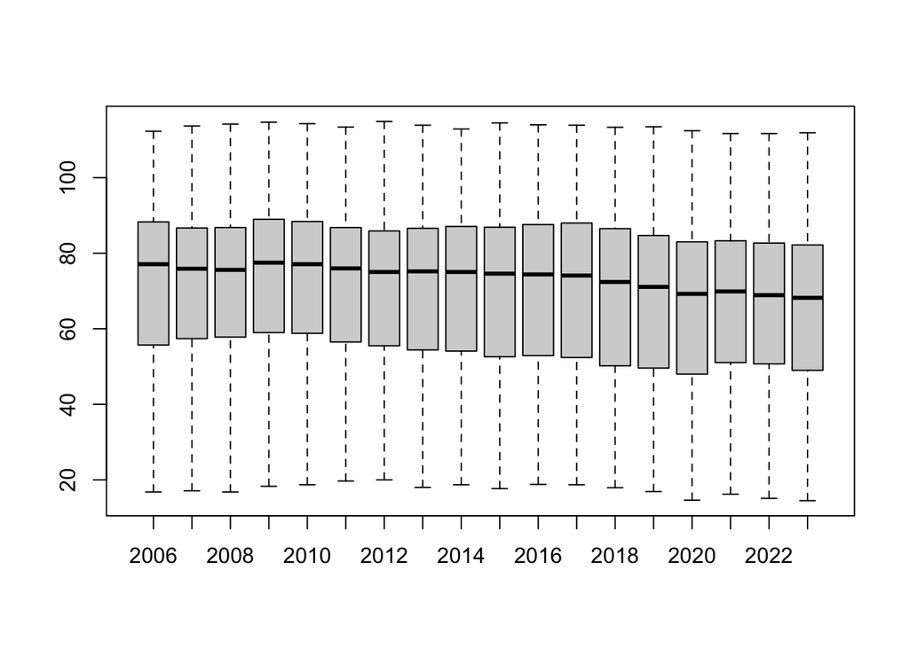

```r
boxplot(fragileWide[,-1])
```

BUT in others such as GGPLOT, it is troublesome to use that format:

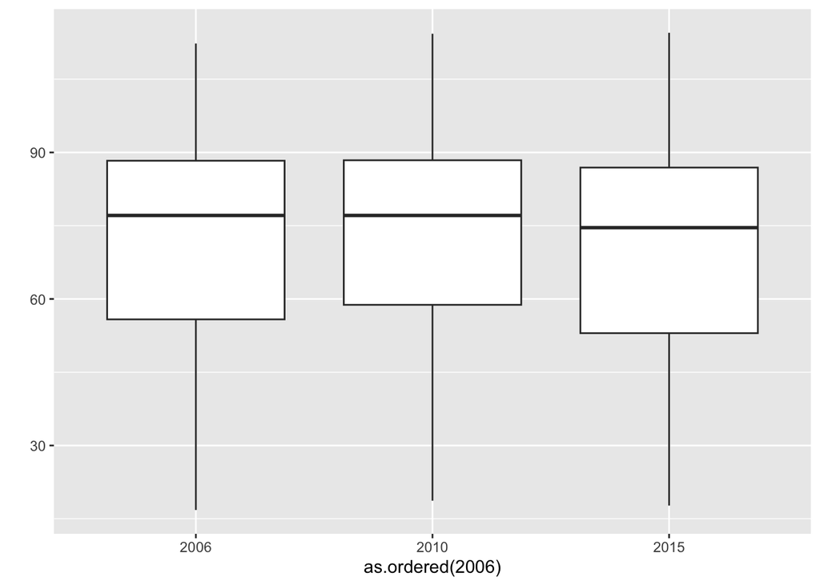

```r
library(ggplot2)
base=ggplot(fragileWide)
base+geom_boxplot(aes(x=as.ordered(2006),y=`2006`)) +
     geom_boxplot(aes(x=as.ordered(2010),y=`2010`)) +
     geom_boxplot(aes(x=as.ordered(2015),y=`2015`)) + labs(y='')
```

### From Wide to Long

We have **pivot_longer** :

```r
fragileLong=tidyr::pivot_longer(fragileWide,!Country, names_to = "Year", values_to = "FragilityIndex")
fragileLong
```

```
## # A tibble: 3,366 × 3
##    Country Year  FragilityIndex
##    <chr>   <chr>          <dbl>
##  1 Somalia 2006            106.
##  2 Somalia 2007            111.
##  3 Somalia 2008            114.
##  4 Somalia 2009            115.
##  5 Somalia 2010            114.
##  6 Somalia 2011            113.
##  7 Somalia 2012            115.
##  8 Somalia 2013            114.
##  9 Somalia 2014            113.
## 10 Somalia 2015            114
## # ℹ 3,356 more rows
```

GGPLOT will work with this:

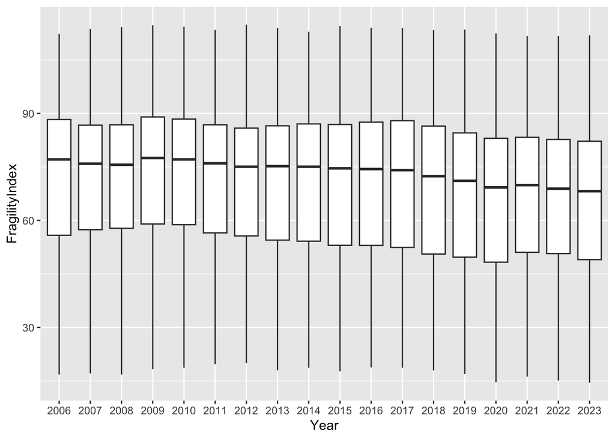

```r
base = ggplot(data=fragileLong)
base + geom_boxplot(aes(x=Year,y=FragilityIndex))
```

We can also use **base R**:

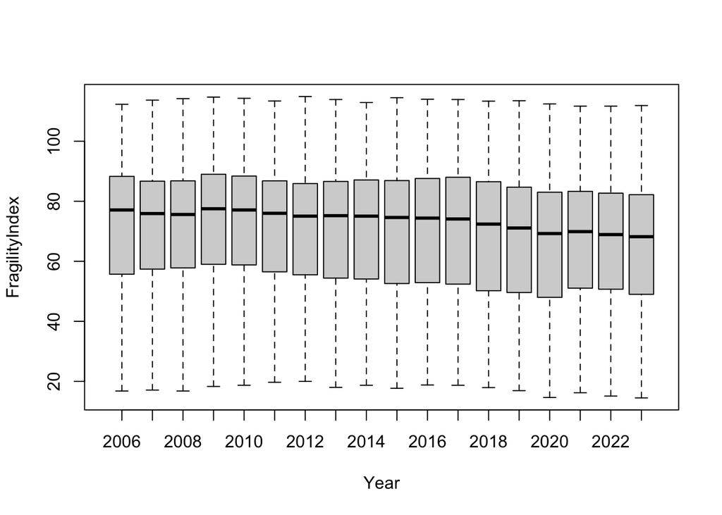

```r
boxplot(data=fragileLong,FragilityIndex~Year)
```

This is another example without years.

Let me keep one year, and some wide-shaped columns:

```r
CVars_columns=c('c1_security_apparatus',    'c2_factionalized_elites',  'c3_group_grievance')

#only one year
fragile_CVars_wide=fragile[fragile$Year==2020,c('Country',CVars_columns)]

# see some
fragile_CVars_wide%>%head(30)
```

```
##                       Country c1_security_apparatus c2_factionalized_elites
## 538                     Yemen              9.700000                  10.000
## 539                   Somalia              9.811328                  10.000
## 540               South Sudan              9.400000                   9.700
## 541                     Syria              9.900000                   9.900
## 542 Congo Democratic Republic              8.500000                   9.800
## 543  Central African Republic              8.300000                   9.682
## 544                      Chad              9.200000                   9.500
## 545                     Sudan              8.377030                   9.400
## 546               Afghanistan              9.932963                   8.900
## 547                  Zimbabwe              8.500000                  10.000
## 548                   Burundi              8.300000                   7.900
## 549                  Cameroon              8.200000                   9.300
## 550                     Haiti              6.900000                   9.579
## 551                   Nigeria              8.700000                   9.900
```

[output cut: 47 more lines]

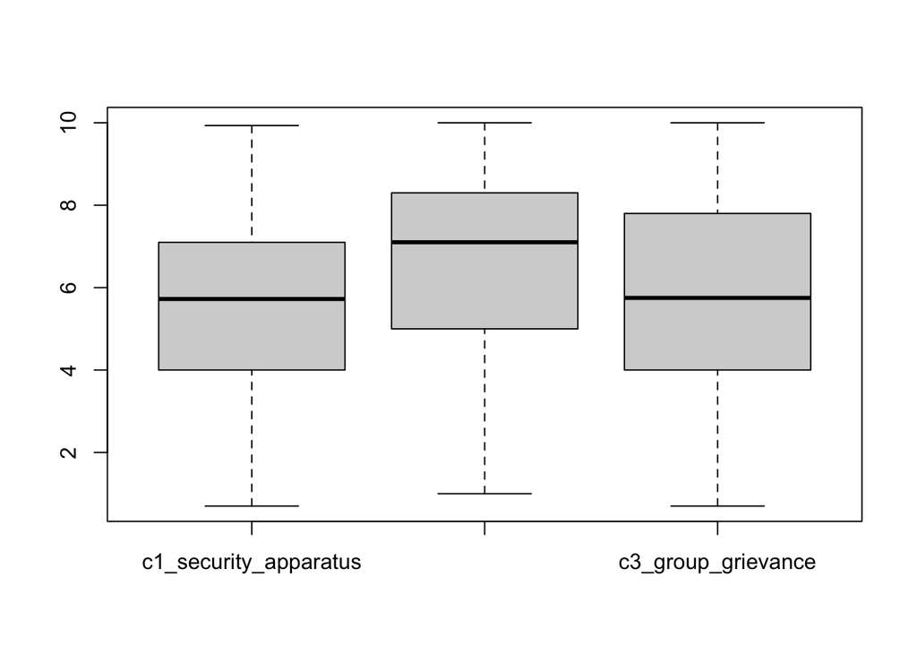

```r
boxplot(fragile_CVars_wide[,-1])
```

```r
fragile_CVars_long=tidyr::pivot_longer(fragile_CVars_wide,!Country, names_to = "CVars_name", values_to = "CVars_value")
fragile_CVars_long
```

```
## # A tibble: 534 × 3
##    Country     CVars_name              CVars_value
##    <chr>       <chr>                         <dbl>
##  1 Yemen       c1_security_apparatus          9.7
##  2 Yemen       c2_factionalized_elites       10
##  3 Yemen       c3_group_grievance             9.70
##  4 Somalia     c1_security_apparatus          9.81
##  5 Somalia     c2_factionalized_elites       10
##  6 Somalia     c3_group_grievance             8.6
##  7 South Sudan c1_security_apparatus          9.4
##  8 South Sudan c2_factionalized_elites        9.7
##  9 South Sudan c3_group_grievance             9.1
## 10 Syria       c1_security_apparatus          9.9
## # ℹ 524 more rows
```

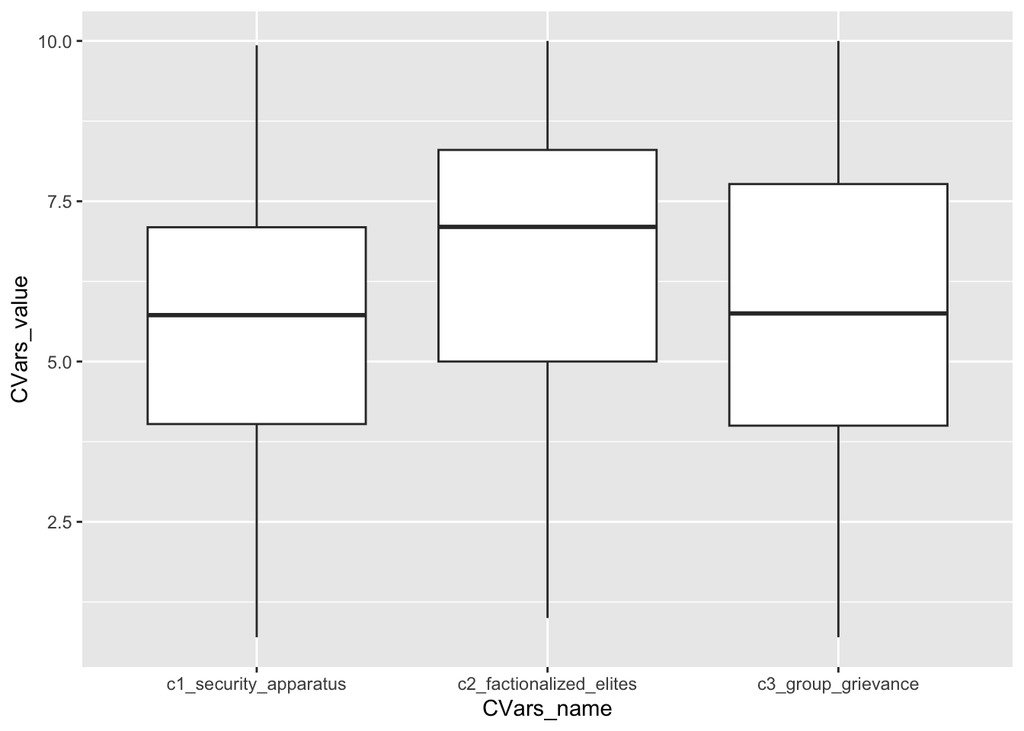

```r
base=ggplot(data=fragile_CVars_long)
base+geom_boxplot(aes(x=CVars_name,y=CVars_value))
```

### LONG and WIDE madness

Let me keep both long and wide elements:

```r
fragile_since2020=fragile[fragile$Year>=2020,c('Country','Year',CVars_columns)]

# see some
fragile_since2020%>%head(30)
```

```
##                      Country Year c1_security_apparatus c2_factionalized_elites
## 1                    Somalia 2023                   9.5                    10.0
## 2                      Yemen 2023                   8.6                     9.9
## 3                South Sudan 2023                   9.9                     9.2
## 4  Congo Democratic Republic 2023                   8.8                     9.6
## 5                      Syria 2023                   9.4                     9.9
## 6                Afghanistan 2023                   9.7                     8.7
## 7                      Sudan 2023                   8.3                     9.6
## 8   Central African Republic 2023                   8.0                     9.4
## 9                       Chad 2023                   8.7                     9.5
## 10                     Haiti 2023                   6.8                     9.7
## 11                  Ethiopia 2023                   8.6                     9.3
## 12                   Myanmar 2023                   9.1                     9.0
## 13                      Mali 2023                   9.6                     7.2
## 14                    Guinea 2023                   8.7                    10.0
```

[output cut: 47 more lines]

See this result when sending a long column into a wide format when other variables are already wide:

```r
fragile_since2020_wide=tidyr::pivot_wider(fragile_since2020,names_from = Year, values_from = all_of(CVars_columns))
fragile_since2020_wide
```

```
## # A tibble: 187 × 13
##    Country  c1_security_apparatu…¹ c1_security_apparatu…² c1_security_apparatu…³
##    <chr>                     <dbl>                  <dbl>                  <dbl>
##  1 Somalia                     9.5                    9.4                    9.3
##  2 Yemen                       8.6                    9.1                    9.4
##  3 South S…                    9.9                    9.8                    9.7
##  4 Congo D…                    8.8                    8.7                    8.6
##  5 Syria                       9.4                    9.5                    9.6
##  6 Afghani…                    9.7                   10                     10
##  7 Sudan                       8.3                    8.2                    8.1
##  8 Central…                    8                      8.3                    8
##  9 Chad                        8.7                    8.6                    8.9
## 10 Haiti                       6.8                    6.3                    6.6
## # ℹ 177 more rows
## # ℹ abbreviated names: ¹c1_security_apparatus_2023,
## #   ²c1_security_apparatus_2022, ³c1_security_apparatus_2021
## # ℹ 9 more variables: c1_security_apparatus_2020 <dbl>,
## #   c2_factionalized_elites_2023 <dbl>, c2_factionalized_elites_2022 <dbl>,
## #   c2_factionalized_elites_2021 <dbl>, c2_factionalized_elites_2020 <dbl>,
## #   c3_group_grievance_2023 <dbl>, c3_group_grievance_2022 <dbl>, …
```

As you saw, the conversion into the wide format changed the column names.

Now, sending the wide columns next to the long column:

```r
fragile_since2020_long=tidyr::pivot_longer(fragile_since2020,
                                           !c(Country,Year),
                                           names_to = "CVars_name",
                                           values_to = "CVars_value")
fragile_since2020_long
```

```
## # A tibble: 2,145 × 4
##    Country                    Year CVars_name              CVars_value
##    <chr>                     <dbl> <chr>                         <dbl>
##  1 Somalia                    2023 c1_security_apparatus           9.5
##  2 Somalia                    2023 c2_factionalized_elites        10
##  3 Somalia                    2023 c3_group_grievance              8.7
##  4 Yemen                      2023 c1_security_apparatus           8.6
##  5 Yemen                      2023 c2_factionalized_elites         9.9
##  6 Yemen                      2023 c3_group_grievance              8.8
##  7 South Sudan                2023 c1_security_apparatus           9.9
##  8 South Sudan                2023 c2_factionalized_elites         9.2
##  9 South Sudan                2023 c3_group_grievance              8.6
## 10 Congo Democratic Republic  2023 c1_security_apparatus           8.8
## # ℹ 2,135 more rows
```

## Merging

Let me bring two data sets. This is their location:

```r
demoIndex="https://docs.google.com/spreadsheets/d/e/2PACX-1vQWJnw11Xd2TvEd0p6_6d2NhtG29T9D_85ooNB4yddfIVH_LBaqiYroAD3sZzD1wvOxBPpj68gPcPsi/pub?gid=0&single=true&output=csv"
debtIndex="https://docs.google.com/spreadsheets/d/e/2PACX-1vQWJnw11Xd2TvEd0p6_6d2NhtG29T9D_85ooNB4yddfIVH_LBaqiYroAD3sZzD1wvOxBPpj68gPcPsi/pub?gid=1301926611&single=true&output=csv"
```

Opening the data frames:

```r
demo=read.csv(demoIndex)
debt=read.csv(debtIndex)
```

The contents of democracy related variables:

```r
str(demo)
```

```
## 'data.frame':    163 obs. of  7 variables:
##  $ geo                   : chr  "afg" "alb" "ago" "arg" ...
##  $ name                  : chr  "Afghanistan" "Albania" "Angola" "Argentina" ...
##  $ ElectoralPluralism    : num  34.2 70 22.5 91.7 75 100 95.8 5 8.3 74.2 ...
##  $ Government            : num  6.4 53.6 28.6 53.6 50 85.7 75 28.6 27.1 60.7 ...
##  $ PoliticalParticipation: num  38.9 44.4 55.6 66.7 61.1 77.8 83.3 33.3 27.8 61.1 ...
##  $ PoliticalCulture      : num  25 62.5 50 56.3 31.3 87.5 68.8 37.5 43.8 56.3 ...
##  $ CivilLiberties        : num  38.2 73.5 26.5 79.4 50 97.1 85.3 29.4 17.6 47.1 ...
```

The contents of public debt:

```r
str(debt)
```

```
## 'data.frame':    207 obs. of  6 variables:
##  $ name               : chr  "Japan" "Greece" "Singapore" "Lebanon" ...
##  $ slug               : chr  "japan" "greece" "singapore" "lebanon" ...
##  $ pct_of_GDP         : num  216 203 150 147 146 ...
##  $ date_of_information: int  2022 2022 2021 2017 2016 2022 2017 2017 2017 2017 ...
##  $ ranking            : int  1 2 3 4 5 6 7 8 9 10 ...
##  $ region             : chr  "East and Southeast Asia" "Europe" "East and Southeast Asia" "Middle East" ...
```

If we are to merge both tables, we do this:

```r
# by.x='name', by.y='name' are NOT NEEDED
merge(demo,debt, by.x='name', by.y='name')
```

```
##                         name geo ElectoralPluralism Government
## 1                Afghanistan afg               34.2        6.4
## 2                    Albania alb               70.0       53.6
## 3                     Angola ago               22.5       28.6
## 4                  Argentina arg               91.7       53.6
## 5                    Armenia arm               75.0       50.0
## 6                  Australia aus              100.0       85.7
## 7                    Austria aut               95.8       75.0
## 8                 Azerbaijan aze                5.0       28.6
## 9                    Bahrain bhr                8.3       27.1
## 10                Bangladesh bgd               74.2       60.7
## 11                   Belarus blr                0.0       20.0
## 12                   Belgium bel               95.8       78.6
## 13                     Benin ben               33.3       53.6
## 14                    Bhutan btn               87.5       67.9
```

[output cut: 577 more lines]

As you see, merge is done, but at the expense of losing countries.

The goal here is to lose less rows. Let’s find out what was not matched in each case:

```r
onlyInDemo=sort(setdiff(demo$name,debt$name))
onlyInDemo
```

```
##  [1] "Cape Verde"       "Congo, Dem. Rep." "Congo, Rep."      "Czech Republic"
##  [5] "Gambia"           "Hong Kong, China" "Kyrgyz Republic"  "Lao"
##  [9] "Macedonia, FYR"   "Myanmar"          "North Korea"      "Palestine"
## [13] "Slovak Republic"  "South Korea"      "Swaziland"        "Turkey"
```

```r
onlyInDebt=sort(setdiff(debt$name,demo$name))
onlyInDebt
```

```
##  [1] "Algeria"                           "American Samoa"
##  [3] "Andorra"                           "Anguilla"
##  [5] "Antigua and Barbuda"               "Aruba"
##  [7] "Bahamas, The"                      "Barbados"
##  [9] "Belize"                            "Bermuda"
## [11] "Brunei"                            "Burma"
## [13] "Cabo Verde"                        "Congo, Democratic Republic of the"
## [15] "Congo, Republic of the"            "Czechia"
## [17] "Dominica"                          "Eswatini"
## [19] "Falkland Islands (Islas Malvinas)" "Faroe Islands"
## [21] "Gambia, The"                       "Greenland"
## [23] "Grenada"                           "Guam"
## [25] "Hong Kong"                         "Iran"
## [27] "Kiribati"                          "Korea, South"
## [29] "Kosovo"                            "Kyrgyzstan"
## [31] "Laos"                              "Lithuania"
## [33] "Macau"                             "Maldives"
## [35] "Marshall Islands"                  "Micronesia, Federated States of"
## [37] "Nauru"                             "New Caledonia"
## [39] "North Macedonia"                   "Northern Mariana Islands"
## [41] "Palau"                             "Puerto Rico"
## [43] "Saint Kitts and Nevis"             "Saint Lucia"
## [45] "Saint Vincent and the Grenadines"  "Samoa"
## [47] "San Marino"                        "Sao Tome and Principe"
## [49] "Seychelles"                        "Slovakia"
## [51] "Solomon Islands"                   "Somalia"
## [53] "South Sudan"                       "Tonga"
## [55] "Turkey (Turkiye)"                  "Tuvalu"
## [57] "Ukraine"                           "Vanuatu"
## [59] "Virgin Islands"                    "West Bank"
```

Let’s install **stringdist**:

```r
# install.packages("stringdist")
```

This is a first try:

```r
TheMatch<-character()
mindist<-integer()
sortedmatches<-character()

for (i in 1:length(onlyInDemo) ) {
  allDistances<-stringdist::stringdist(onlyInDemo[i],onlyInDebt,method = 'jw')
  mindist[i]=min(allDistances)
  TheMatch[i]<-onlyInDebt[which.min(allDistances)]
}
fuzzyOutput=data.frame(input=onlyInDemo,possible_match=TheMatch,divergence=mindist,  stringsAsFactors = F)

fuzzyOutput[order(-fuzzyOutput$divergence),]
```

```
##               input                    possible_match divergence
## 12        Palestine                          Eswatini 0.33981481
## 10          Myanmar                             Macau 0.32380952
## 15        Swaziland                           Somalia 0.31005291
## 4    Czech Republic                           Czechia 0.30952381
## 9    Macedonia, FYR                             Macau 0.30476190
## 7   Kyrgyz Republic            Congo, Republic of the 0.29292929
## 13  Slovak Republic                          Slovakia 0.28333333
## 1        Cape Verde                        Cabo Verde 0.25833333
## 14      South Korea                       South Sudan 0.24242424
## 2  Congo, Dem. Rep. Congo, Democratic Republic of the 0.23358586
## 11      North Korea                   North Macedonia 0.23097643
## 3       Congo, Rep.            Congo, Republic of the 0.21212121
## 16           Turkey                  Turkey (Turkiye) 0.20833333
## 5            Gambia                       Gambia, The 0.15151515
## 6  Hong Kong, China                         Hong Kong 0.14583333
## 8               Lao                              Laos 0.08333333
```

We can keep matches above some threshold:

```r
best_fuzzy_1=fuzzyOutput[fuzzyOutput$divergence<=0.23,]
best_fuzzy_1
```

```
##               input         possible_match divergence
## 3       Congo, Rep. Congo, Republic of the 0.21212121
## 5            Gambia            Gambia, The 0.15151515
## 6  Hong Kong, China              Hong Kong 0.14583333
## 8               Lao                   Laos 0.08333333
## 16           Turkey       Turkey (Turkiye) 0.20833333
```

Here we update with the matches:

```r
demo$name[match(best_fuzzy_1$input, demo$name)] = best_fuzzy_1$possible_match
```

And redo previous steps:

```r
onlyInDemo=sort(setdiff(demo$name,debt$name))
onlyInDebt=sort(setdiff(debt$name,demo$name))

TheMatch<-character()
mindist<-integer()
sortedmatches<-character()

for (i in 1:length(onlyInDemo) ) {
  allDistances<-stringdist::stringdist(onlyInDemo[i],onlyInDebt,method = 'jw')
  mindist[i]=min(allDistances)
  TheMatch[i]<-onlyInDebt[which.min(allDistances)]
}
fuzzyOutput=data.frame(input=onlyInDemo,possible_match=TheMatch,divergence=mindist,  stringsAsFactors = F)

fuzzyOutput[order(-fuzzyOutput$divergence),]
```

```
##               input                    possible_match divergence
## 8         Palestine                          Eswatini  0.3398148
## 4   Kyrgyz Republic                        Kyrgyzstan  0.3333333
## 6           Myanmar                             Macau  0.3238095
## 11        Swaziland                           Somalia  0.3100529
## 3    Czech Republic                           Czechia  0.3095238
## 5    Macedonia, FYR                             Macau  0.3047619
## 9   Slovak Republic                          Slovakia  0.2833333
## 1        Cape Verde                        Cabo Verde  0.2583333
## 10      South Korea                       South Sudan  0.2424242
## 2  Congo, Dem. Rep. Congo, Democratic Republic of the  0.2335859
## 7       North Korea                   North Macedonia  0.2309764
```

We can choose some rows:

```r
best_fuzzy_2=fuzzyOutput[c(4,3,9,1,2),]
best_fuzzy_2
```

```
##              input                    possible_match divergence
## 4  Kyrgyz Republic                        Kyrgyzstan  0.3333333
## 3   Czech Republic                           Czechia  0.3095238
## 9  Slovak Republic                          Slovakia  0.2833333
## 1       Cape Verde                        Cabo Verde  0.2583333
## 2 Congo, Dem. Rep. Congo, Democratic Republic of the  0.2335859
```

And then update and retry:

```r
demo$name[match(best_fuzzy_2$input, demo$name)] = best_fuzzy_2$possible_match

onlyInDemo=sort(setdiff(demo$name,debt$name))
onlyInDebt=sort(setdiff(debt$name,demo$name))

TheMatch<-character()
mindist<-integer()
sortedmatches<-character()

for (i in 1:length(onlyInDemo) ) {
  allDistances<-stringdist::stringdist(onlyInDemo[i],onlyInDebt,method = 'jw')
  mindist[i]=min(allDistances)
  TheMatch[i]<-onlyInDebt[which.min(allDistances)]
}
fuzzyOutput=data.frame(input=onlyInDemo,possible_match=TheMatch,divergence=mindist,  stringsAsFactors = F)

fuzzyOutput[order(-fuzzyOutput$divergence),]
```

```
##            input  possible_match divergence
## 4      Palestine        Eswatini  0.3398148
## 2        Myanmar           Macau  0.3238095
## 6      Swaziland         Somalia  0.3100529
## 1 Macedonia, FYR           Macau  0.3047619
## 5    South Korea     South Sudan  0.2424242
## 3    North Korea North Macedonia  0.2309764
```

The algorithm can be changed:

```r
TheMatch<-character()
mindist<-integer()
sortedmatches<-character()

for (i in 1:length(onlyInDemo) ) {
  allDistances<-stringdist::stringdist(onlyInDemo[i],onlyInDebt,method = 'cosine')
  mindist[i]=min(allDistances)
  TheMatch[i]<-onlyInDebt[which.min(allDistances)]
}
fuzzyOutput=data.frame(input=onlyInDemo,possible_match=TheMatch,divergence=mindist,  stringsAsFactors = F)

fuzzyOutput[order(-fuzzyOutput$divergence),]
```

```
##            input                  possible_match divergence
## 6      Swaziland                         Somalia 0.29647353
## 4      Palestine Micronesia, Federated States of 0.28762379
## 2        Myanmar                      San Marino 0.28730335
## 1 Macedonia, FYR                 North Macedonia 0.25439886
## 3    North Korea                    Korea, South 0.17192133
## 5    South Korea                    Korea, South 0.03637589
```

So, we recovered more:

```r
best_fuzzy_3=fuzzyOutput[c(1,5),]
best_fuzzy_3
```

```
##            input  possible_match divergence
## 1 Macedonia, FYR North Macedonia 0.25439886
## 5    South Korea    Korea, South 0.03637589
```

We could add some manually:

```r
best_fuzzy_3=rbind(best_fuzzy_3,c('Swaziland','Eswatini',NA))
best_fuzzy_3
```

```
##            input  possible_match         divergence
## 1 Macedonia, FYR North Macedonia  0.254398864920674
## 5    South Korea    Korea, South 0.0363758883405684
## 3      Swaziland        Eswatini               <NA>
```

Then update:

```r
demo$name[match(best_fuzzy_3$input, demo$name)] = best_fuzzy_3$possible_match
```

We should stop here, and get the best posible merge:

```r
demodebt=merge(demo,debt, by.x='name', by.y='name')
str(demodebt)
```

```
## 'data.frame':    160 obs. of  12 variables:
##  $ name                  : chr  "Afghanistan" "Albania" "Angola" "Argentina" ...
##  $ geo                   : chr  "afg" "alb" "ago" "arg" ...
##  $ ElectoralPluralism    : num  34.2 70 22.5 91.7 75 100 95.8 5 8.3 74.2 ...
##  $ Government            : num  6.4 53.6 28.6 53.6 50 85.7 75 28.6 27.1 60.7 ...
##  $ PoliticalParticipation: num  38.9 44.4 55.6 66.7 61.1 77.8 83.3 33.3 27.8 61.1 ...
##  $ PoliticalCulture      : num  25 62.5 50 56.3 31.3 87.5 68.8 37.5 43.8 56.3 ...
##  $ CivilLiberties        : num  38.2 73.5 26.5 79.4 50 97.1 85.3 29.4 17.6 47.1 ...
##  $ slug                  : chr  "afghanistan" "albania" "angola" "argentina" ...
##  $ pct_of_GDP            : num  7 82.4 65 57.6 46.5 ...
##  $ date_of_information   : int  2017 2021 2017 2017 2022 2022 2022 2021 2020 2017 ...
##  $ ranking               : int  198 35 64 86 118 84 46 192 13 162 ...
##  $ region                : chr  "South Asia" "Europe" "Africa" "South America" ...
```